# Weather Retrieval

Jeff Allen

10/13/2014

We’ll now go fetch the weather for the relevant window of time in a zip code in Lake County, CA. [`95423` looks central](http://www.zipmap.net/California/Lake_County.htm) to the area, so we’ll use that zip code.

This code assumes that you’ve stored your Weather Underground API key in a file named `wu-key.txt` (sorry, you can’t use mine). You’ll need to sign up for one at http://www.wunderground.com/weather/api/. You can then set the `sleepInterval` to whatever number of seconds is appropriate to keep you from exceeding your quotas for API hits on the service.

```r
source("Weather/DownloadHistoric.R")
source("Weather/getRecords.R")

wu_key <- readChar("wu-key.txt", nchars=100)

library(lubridate)

start <- "2011-09-24"
end <- "2014-09-24"

weather <- getWeather(wu_key = wu_key, zip=95423, startDate=start, endDate=end, sleepInterval = 7, outputFile = "weather.Rds")
```

In total, we got 1098 entries. For each day, we have the following fields:

```r
library(lubridate)
# We get an extra `zip` entry on the front.
weather <- weather[2:length(weather)]
names(weather[[1]])
```

```
##  [1] "date"
##  [2] "fog"
##  [3] "rain"
##  [4] "snow"
##  [5] "snowfallm"
##  [6] "snowfalli"
##  [7] "monthtodatesnowfallm"
##  [8] "monthtodatesnowfalli"
##  [9] "since1julsnowfallm"
## [10] "since1julsnowfalli"
## [11] "snowdepthm"
## [12] "snowdepthi"
## [13] "hail"
## [14] "thunder"
## [15] "tornado"
```

[output cut: 55 more lines]

We’ll use `precipi` to inform us regarding how many inches of precipitation fell that day. The shape of the data is:

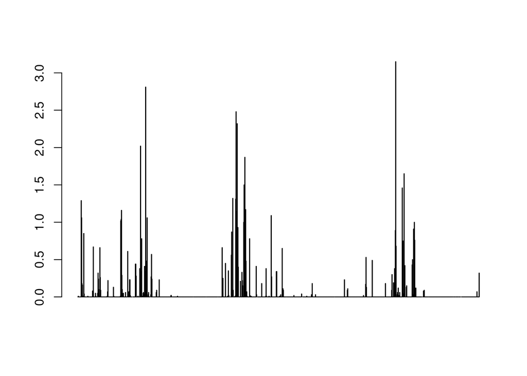

```r
barplot(as.numeric(sapply(weather, "[[", "precipi")))
```

There are a few days with weird data (`"T"` for precipitation values, for instance). The one day I checked on which `precip == T` was 0 inches of rain/snow, so we’ll just leave NAs as-is and assume they indicate no precipitation.

The temperature probably might affect crime, too. Let’s see what the temperature looks like.

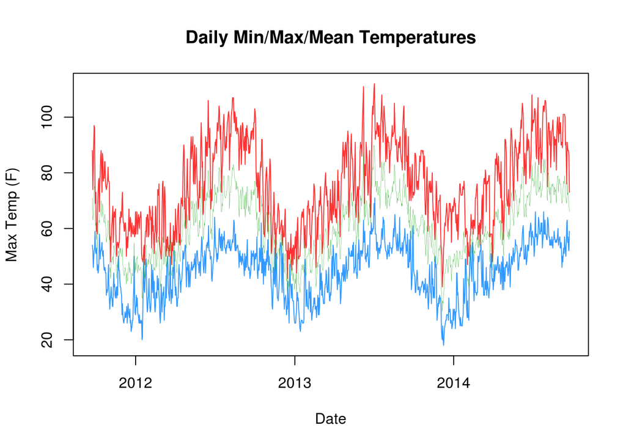

```r
maxT <- as.numeric(sapply(weather, "[[", "maxtempi"))
minT <- as.numeric(sapply(weather, "[[", "mintempi"))
meanT <- as.numeric(sapply(weather, "[[", "meantempi"))

dates <- sapply(weather, function(x){
  x <- x$date
  str <- paste0(x["year"], "-", x["mon"], "-", x["mday"])
  return(str)
})
dates <- ymd(dates)

plot(dates, maxT, type="l", ylim=c(min(minT), max(maxT)), col="#FF3333", main="Daily Min/Max/Mean Temperatures", ylab="Max Temp (F)", xlab="Date")
lines(dates, minT, type="l", col="#3399FF")
lines(dates, meanT, type="l", col="#009900", lwd=0.2)
```